# Catalog v6.0 preparation: v0.4.1 grids and NLL-SSST test

Track B, D-B092 (PI 2026-11-25), implements D-B079. Generated by workflow/10_tomography/b4_v6_ssst_report.py (branch reloc/v6-prep).

## Cluster tests, grids g51: v5.1 production grids (model v0.3.1 + D-B073 field rule): method test, not the v6.0 model

### axial

| arm | located | tier A-B | above surface | floor-limited | median depth km | depth below seafloor km | Axial A-B within 2 km of seafloor % | P rms s | S rms s | CC pair MAD ms (P / S) | catalog-dt pair MAD ms | repeater distance km (median) | nearest neighbour km | moved vs static: dh / dz km |
| --- | --- | --- | --- | --- | --- | --- | --- | --- | --- | --- | --- | --- | --- | --- |
| v5.1 catalog (tile box) | 1,200 | 1,190 | 0 | 39 | 3.00 | 1.48 | 91.3 |  |  |  |  | 0.114 | 0.000 | 0.033 / -0.000 |
| static terms (v5.1 file) | 1,200 | 1,191 | 0 | 40 | 3.00 | 1.48 | 91.4 | 0.076 | 0.120 | 12.3 (10.7 / 15.8) | 23.1 | 0.134 | 0.068 |  |
| no terms (it0) | 1,200 | 1,190 | 0 | 12 | 3.00 | 1.48 | 91.1 | 0.087 | 0.187 | 17.0 (14.4 / 22.0) | 25.3 | 0.217 | 0.068 | 0.180 / 0.000 |
| SSST it1 (static, 9999 km) | 1,200 | 1,191 | 0 | 61 | 3.00 | 1.48 | 89.1 | 0.067 | 0.089 | 13.5 (11.6 / 17.6) | 23.2 | 0.187 | 0.068 | 0.114 / 0.000 |
| SSST it2 (16 km) | 1,200 | 1,191 | 0 | 76 | 3.00 | 1.49 | 88.5 | 0.065 | 0.089 | 14.6 (12.7 / 19.0) | 23.5 | 0.229 | 0.068 | 0.128 / 0.037 |
| SSST it3 (8 km) | 1,200 | 1,191 | 0 | 79 | 3.04 | 1.52 | 88.1 | 0.065 | 0.089 | 15.1 (13.0 / 19.6) | 23.8 | 0.234 | 0.068 | 0.161 / 0.074 |
| SSST it4 (4 km) | 1,200 | 1,191 | 0 | 86 | 3.04 | 1.52 | 87.3 | 0.065 | 0.089 | 15.1 (12.8 / 19.7) | 23.8 | 0.233 | 0.068 | 0.161 / 0.074 |
| SSST final it5 (2 km) | 1,200 | 1,191 | 0 | 111 | 3.04 | 1.52 | 85.7 | 0.065 | 0.088 | 15.2 (12.7 / 20.4) | 23.8 | 0.242 | 0.068 | 0.161 / 0.074 |
| SSST + coherence | 1,200 | 1,191 | 0 | 30 | 3.10 | 1.57 | 85.6 | 0.066 | 0.092 | 11.2 (10.2 / 13.3) | 23.1 | 0.089 | 0.034 | 0.115 / 0.092 |
| static + coherence | 1,200 | 1,192 | 0 | 26 | 3.02 | 1.50 | 92.4 | 0.075 | 0.123 | 11.2 (9.9 / 13.6) | 22.7 | 0.074 | 0.031 | 0.064 / 0.018 |

SSST + coherence: 1178 of 1200 events relocated (ellipsoid len3 ≤ 5.0 km), 1174 with at least one partner of coherence ≥ 0.5 that passes the same filter; 8555 pairs.

static + coherence: 1179 of 1200 events relocated (ellipsoid len3 ≤ 5.0 km), 1175 with at least one partner of coherence ≥ 0.5 that passes the same filter; 8555 pairs.

Loc2ssst runs: ssst_it0: CharDist 9999 km, 1200 events, 16 grids, 1 negative nodes (max 0.44 km from the station), 1 s; ssst_it1: CharDist 16 km, 1200 events, 16 grids, 3 negative nodes (max 0.58 km from the station), 1 s; ssst_it2: CharDist 8 km, 1199 events, 16 grids, 3 negative nodes (max 0.58 km from the station), 1 s; ssst_it3: CharDist 4 km, 1199 events, 16 grids, 3 negative nodes (max 0.58 km from the station), 7 s; ssst_it4: CharDist 2 km, 1199 events, 16 grids, 3 negative nodes (max 0.58 km from the station), 28 s

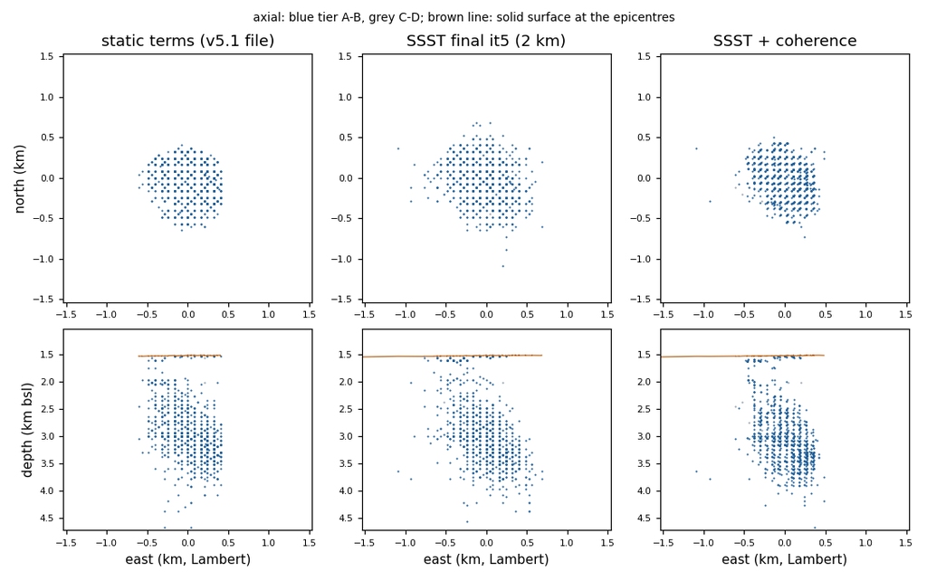

### blanco

| arm | located | tier A-B | above surface | floor-limited | median depth km | depth below seafloor km | P rms s | S rms s | CC pair MAD ms (P / S) | catalog-dt pair MAD ms | repeater distance km (median) | nearest neighbour km | moved vs static: dh / dz km |
| --- | --- | --- | --- | --- | --- | --- | --- | --- | --- | --- | --- | --- | --- |
| v5.1 catalog (tile box) | 1,044 | 0 | 0 | 3 | 5.66 | 2.28 |  |  |  |  | 0.440 | 0.237 | 0.051 / -0.000 |
| static terms (v5.1 file) | 1,044 | 0 | 0 | 3 | 5.66 | 2.29 | 0.250 | 0.190 | 24.3 (19.1 / 30.7) | 33.8 | 0.449 | 0.237 |  |
| no terms (it0) | 1,044 | 0 | 0 | 6 | 5.40 | 2.08 | 0.310 | 0.305 | 35.6 (27.7 / 43.6) | 42.2 | 0.752 | 0.279 | 0.575 / -0.221 |
| SSST it1 (static, 9999 km) | 1,044 | 0 | 0 | 2 | 5.51 | 2.19 | 0.126 | 0.142 | 24.7 (19.6 / 31.5) | 33.9 | 0.464 | 0.229 | 0.273 / -0.111 |
| SSST it2 (16 km) | 1,044 | 0 | 0 | 2 | 5.59 | 2.22 | 0.113 | 0.131 | 24.0 (19.0 / 30.6) | 33.0 | 0.425 | 0.237 | 0.221 / -0.074 |
| SSST it3 (8 km) | 1,044 | 0 | 0 | 1 | 5.59 | 2.23 | 0.110 | 0.122 | 24.0 (19.1 / 30.5) | 32.6 | 0.411 | 0.242 | 0.237 / -0.074 |
| SSST it4 (4 km) | 1,044 | 0 | 0 | 1 | 5.59 | 2.24 | 0.106 | 0.115 | 23.2 (18.6 / 29.7) | 32.5 | 0.359 | 0.235 | 0.237 / -0.018 |
| SSST final it5 (2 km) | 1,044 | 0 | 0 | 1 | 5.59 | 2.25 | 0.103 | 0.107 | 24.0 (19.4 / 29.4) | 31.9 | 0.461 | 0.239 | 0.249 / 0.000 |
| SSST + coherence | 1,044 | 0 | 0 | 1 | 5.59 | 2.25 | 0.103 | 0.108 | 23.5 (19.0 / 28.8) | 31.9 | 0.449 | 0.235 | 0.249 / 0.000 |
| static + coherence | 1,044 | 0 | 0 | 3 | 5.66 | 2.29 | 0.250 | 0.190 | 24.3 (19.1 / 30.7) | 33.8 | 0.449 | 0.237 | 0.000 / 0.000 |

Depth minus published depth (Lange et al. 2026), km, positive = ours deeper:

[output not shown]

SSST + coherence: 74 of 1044 events relocated (ellipsoid len3 ≤ 5.0 km), 63 with at least one partner of coherence ≥ 0.5 that passes the same filter; 10909 pairs.

static + coherence: 35 of 1044 events relocated (ellipsoid len3 ≤ 5.0 km), 24 with at least one partner of coherence ≥ 0.5 that passes the same filter; 10909 pairs.

Loc2ssst runs: ssst_it0: CharDist 9999 km, 1026 events, 63 grids, 0 negative nodes (max 0 km from the station), 2 s; ssst_it1: CharDist 16 km, 1037 events, 63 grids, 0 negative nodes (max 0 km from the station), 2 s; ssst_it2: CharDist 8 km, 1038 events, 63 grids, 0 negative nodes (max 0 km from the station), 2 s; ssst_it3: CharDist 4 km, 1039 events, 63 grids, 0 negative nodes (max 0 km from the station), 7 s; ssst_it4: CharDist 2 km, 1038 events, 63 grids, 0 negative nodes (max 0 km from the station), 36 s

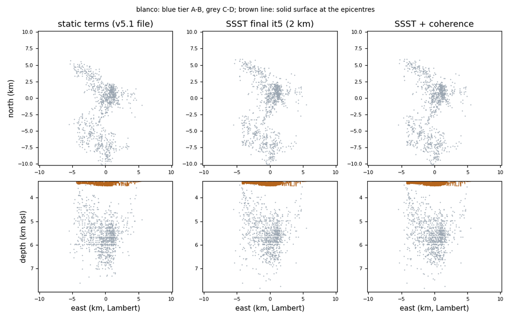

### msh

| arm | located | tier A-B | above surface | floor-limited | median depth km | depth below seafloor km | P rms s | S rms s | CC pair MAD ms (P / S) | catalog-dt pair MAD ms | repeater distance km (median) | nearest neighbour km | moved vs static: dh / dz km |
| --- | --- | --- | --- | --- | --- | --- | --- | --- | --- | --- | --- | --- | --- |
| v5.1 catalog (tile box) | 1,436 | 1,311 | 0 | 0 | 1.18 | 3.25 |  |  |  |  | 0.215 | 0.084 | 0.026 / 0.000 |
| static terms (v5.1 file) | 1,436 | 1,333 | 0 | 1 | 1.18 | 3.25 | 0.124 | 0.199 | 17.2 (14.5 / 24.5) | 37.9 | 0.219 | 0.085 |  |
| no terms (it0) | 1,436 | 1,313 | 0 | 8 | 1.81 | 3.86 | 0.164 | 0.288 | 30.8 (26.4 / 41.9) | 46.7 | 0.498 | 0.113 | 0.281 / 0.516 |
| SSST it1 (static, 9999 km) | 1,436 | 1,332 | 0 | 1 | 1.68 | 3.74 | 0.114 | 0.178 | 17.7 (15.1 / 24.3) | 37.7 | 0.242 | 0.083 | 0.151 / 0.516 |
| SSST it2 (16 km) | 1,436 | 1,333 | 0 | 1 | 1.55 | 3.64 | 0.112 | 0.172 | 17.3 (15.1 / 23.1) | 36.9 | 0.220 | 0.074 | 0.156 / 0.378 |
| SSST it3 (8 km) | 1,436 | 1,334 | 0 | 1 | 1.47 | 3.57 | 0.111 | 0.170 | 17.3 (15.2 / 22.5) | 36.8 | 0.215 | 0.070 | 0.167 / 0.295 |
| SSST it4 (4 km) | 1,436 | 1,334 | 0 | 3 | 1.43 | 3.50 | 0.109 | 0.168 | 17.1 (15.1 / 22.1) | 36.8 | 0.219 | 0.070 | 0.171 / 0.258 |
| SSST final it5 (2 km) | 1,436 | 1,335 | 0 | 3 | 1.40 | 3.48 | 0.106 | 0.164 | 16.9 (15.0 / 21.5) | 36.5 | 0.270 | 0.073 | 0.172 / 0.258 |
| SSST + coherence | 1,436 | 1,333 | 0 | 2 | 1.41 | 3.47 | 0.120 | 0.190 | 9.6 (8.9 / 11.4) | 35.9 | 0.070 | 0.042 | 0.185 / 0.230 |
| static + coherence | 1,436 | 1,333 | 0 | 1 | 1.19 | 3.28 | 0.125 | 0.203 | 10.6 (9.8 / 12.3) | 36.2 | 0.074 | 0.056 | 0.075 / 0.009 |

Depth minus published depth (Hirao et al. 2025), km, positive = ours deeper:

| arm | tiers A-D: median [p10, p90] | tiers A-B |
| --- | --- | --- |
| v5.1 catalog (tile box) | +0.92 [-0.4, +2.2] n=1258 | +0.95 [-0.4, +2.2] n=1171 |
| static terms (v5.1 file) | +0.91 [-0.4, +2.2] n=1258 | +0.94 [-0.4, +2.2] n=1183 |
| no terms (it0) | +1.59 [-0.0, +3.0] n=1258 | +1.61 [+0.0, +2.9] n=1170 |
| SSST it1 (static, 9999 km) | +1.43 [+0.2, +2.5] n=1258 | +1.44 [+0.2, +2.5] n=1183 |
| SSST it2 (16 km) | +1.32 [+0.1, +2.4] n=1258 | +1.33 [+0.1, +2.4] n=1184 |
| SSST it3 (8 km) | +1.24 [+0.0, +2.3] n=1258 | +1.26 [+0.0, +2.3] n=1185 |
| SSST it4 (4 km) | +1.20 [-0.0, +2.3] n=1258 | +1.21 [-0.0, +2.3] n=1183 |
| SSST final it5 (2 km) | +1.16 [-0.0, +2.4] n=1258 | +1.20 [-0.0, +2.4] n=1186 |
| SSST + coherence | +1.16 [+0.0, +2.3] n=1258 | +1.18 [+0.0, +2.3] n=1184 |
| static + coherence | +0.95 [-0.4, +2.3] n=1258 | +0.97 [-0.4, +2.3] n=1183 |

SSST + coherence: 1280 of 1436 events relocated (ellipsoid len3 ≤ 5.0 km), 1273 with at least one partner of coherence ≥ 0.5 that passes the same filter; 12581 pairs.

static + coherence: 1284 of 1436 events relocated (ellipsoid len3 ≤ 5.0 km), 1277 with at least one partner of coherence ≥ 0.5 that passes the same filter; 12581 pairs.

Loc2ssst runs: ssst_it0: CharDist 9999 km, 1380 events, 204 grids, 18 negative nodes (max 0.86 km from the station), 5 s; ssst_it1: CharDist 16 km, 1386 events, 204 grids, 19 negative nodes (max 0.86 km from the station), 4 s; ssst_it2: CharDist 8 km, 1387 events, 204 grids, 22 negative nodes (max 0.87 km from the station), 4 s; ssst_it3: CharDist 4 km, 1388 events, 204 grids, 20 negative nodes (max 0.87 km from the station), 14 s; ssst_it4: CharDist 2 km, 1388 events, 204 grids, 20 negative nodes (max 0.87 km from the station), 83 s

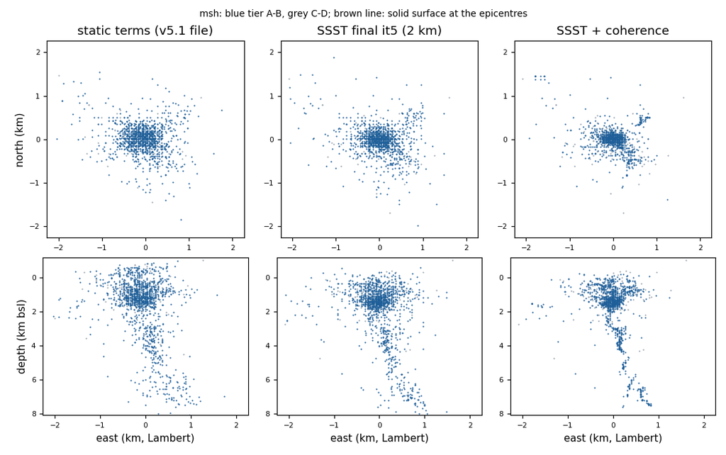

### jdf

| arm | located | tier A-B | above surface | floor-limited | median depth km | depth below seafloor km | P rms s | S rms s | CC pair MAD ms (P / S) | catalog-dt pair MAD ms | repeater distance km (median) | nearest neighbour km | moved vs static: dh / dz km |
| --- | --- | --- | --- | --- | --- | --- | --- | --- | --- | --- | --- | --- | --- |
| v5.1 catalog (tile box) | 162 | 0 | 0 | 156 | 2.75 | 0.02 |  |  |  |  | 0.473 | 0.161 | 0.055 / 0.000 |
| static terms (v5.1 file) | 162 | 0 | 0 | 153 | 2.75 | 0.02 | 0.134 | 0.251 | 39.0 (28.0 / 52.4) | 55.8 | 0.539 | 0.156 |  |
| no terms (it0) | 162 | 0 | 0 | 139 | 2.75 | 0.02 | 0.186 | 0.364 | 62.2 (45.1 / 83.2) | 76.2 | 0.988 | 0.212 | 0.488 / 0.000 |
| SSST it1 (static, 9999 km) | 162 | 0 | 0 | 129 | 2.75 | 0.03 | 0.119 | 0.214 | 35.8 (27.5 / 45.6) | 51.2 | 0.448 | 0.159 | 0.156 / 0.000 |
| SSST it2 (16 km) | 162 | 1 | 0 | 88 | 2.78 | 0.08 | 0.108 | 0.169 | 35.7 (29.9 / 43.1) | 49.6 | 0.438 | 0.178 | 0.234 / 0.055 |
| SSST it3 (8 km) | 162 | 0 | 0 | 38 | 3.26 | 0.54 | 0.105 | 0.158 | 41.7 (33.9 / 53.0) | 47.2 | 0.709 | 0.310 | 0.302 / 0.470 |
| SSST it4 (4 km) | 162 | 1 | 0 | 25 | 3.45 | 0.72 | 0.098 | 0.101 | 37.9 (31.2 / 48.4) | 46.7 | 0.634 | 0.354 | 0.323 / 0.655 |
| SSST final it5 (2 km) | 162 | 2 | 0 | 23 | 4.07 | 1.41 | 0.087 | 0.095 | 40.9 (33.1 / 52.1) | 45.3 | 0.646 | 0.345 | 0.323 / 0.830 |
| SSST + coherence | 162 | 2 | 0 | 23 | 4.07 | 1.41 | 0.087 | 0.096 | 40.8 (33.5 / 51.1) | 46.2 | 0.646 | 0.345 | 0.324 / 0.830 |
| static + coherence | 162 | 0 | 0 | 153 | 2.75 | 0.02 | 0.134 | 0.251 | 39.0 (28.0 / 52.4) | 55.8 | 0.539 | 0.156 | 0.000 / 0.000 |

SSST + coherence: 7 of 162 events relocated (ellipsoid len3 ≤ 5.0 km), 7 with at least one partner of coherence ≥ 0.5 that passes the same filter; 2039 pairs.

static + coherence: 1 of 162 events relocated (ellipsoid len3 ≤ 5.0 km), 0 with at least one partner of coherence ≥ 0.5 that passes the same filter; 2039 pairs.

Loc2ssst runs: ssst_it0: CharDist 9999 km, 117 events, 16 grids, 1 negative nodes (max 0 km from the station), 0 s; ssst_it1: CharDist 16 km, 138 events, 16 grids, 1 negative nodes (max 0 km from the station), 0 s; ssst_it2: CharDist 8 km, 136 events, 16 grids, 2 negative nodes (max 0 km from the station), 0 s; ssst_it3: CharDist 4 km, 162 events, 16 grids, 3 negative nodes (max 0 km from the station), 1 s; ssst_it4: CharDist 2 km, 162 events, 16 grids, 3 negative nodes (max 0 km from the station), 4 s

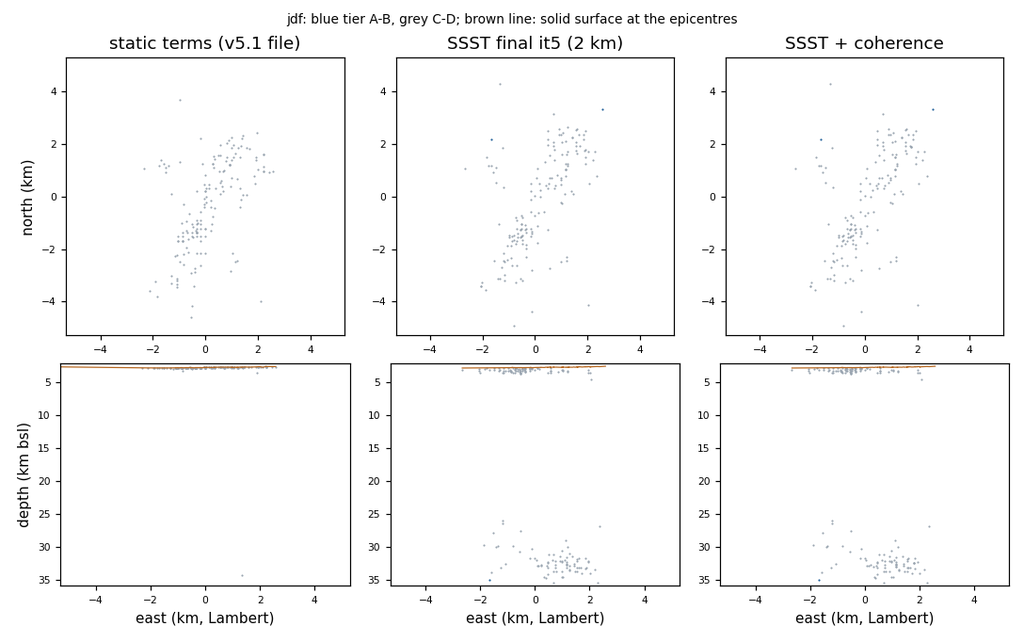

## Cluster tests, grids g041: v6.0 grids (model v0.4.1)

### axial

| arm | located | tier A-B | above surface | floor-limited | median depth km | depth below seafloor km | Axial A-B within 2 km of seafloor % | P rms s | S rms s | CC pair MAD ms (P / S) | catalog-dt pair MAD ms | repeater distance km (median) | nearest neighbour km | moved vs static: dh / dz km |
| --- | --- | --- | --- | --- | --- | --- | --- | --- | --- | --- | --- | --- | --- | --- |
| v5.1 catalog (tile box) | 1,200 | 1,190 | 0 | 39 | 3.00 | 1.48 | 91.3 |  |  |  |  | 0.114 | 0.000 |  |
| no terms (it0) | 1,200 | 1,191 | 0 | 12 | 3.00 | 1.48 | 91.2 | 0.087 | 0.188 | 17.0 (14.4 / 22.1) | 25.3 | 0.233 | 0.068 |  |
| SSST it1 (static, 9999 km) | 1,200 | 1,191 | 0 | 62 | 3.00 | 1.48 | 89.2 | 0.067 | 0.089 | 13.4 (11.5 / 17.6) | 23.3 | 0.187 | 0.068 |  |
| SSST it2 (16 km) | 1,200 | 1,191 | 0 | 75 | 3.00 | 1.49 | 88.7 | 0.065 | 0.089 | 14.7 (12.7 / 19.1) | 23.4 | 0.229 | 0.068 |  |
| SSST it3 (8 km) | 1,200 | 1,191 | 0 | 79 | 3.04 | 1.52 | 88.2 | 0.065 | 0.089 | 15.1 (12.9 / 19.8) | 23.9 | 0.234 | 0.068 |  |
| SSST it4 (4 km) | 1,200 | 1,191 | 0 | 85 | 3.04 | 1.52 | 87.6 | 0.065 | 0.089 | 15.2 (12.9 / 20.0) | 23.9 | 0.233 | 0.068 |  |
| SSST final it5 (2 km) | 1,200 | 1,191 | 0 | 112 | 3.04 | 1.52 | 86.1 | 0.065 | 0.088 | 15.2 (12.6 / 20.5) | 23.9 | 0.234 | 0.068 |  |
| SSST + coherence | 1,200 | 1,191 | 0 | 30 | 3.10 | 1.57 | 86.2 | 0.066 | 0.093 | 11.2 (10.2 / 13.5) | 23.0 | 0.081 | 0.034 |  |

SSST + coherence: 1176 of 1200 events relocated (ellipsoid len3 ≤ 5.0 km), 1172 with at least one partner of coherence ≥ 0.5 that passes the same filter; 8555 pairs.

Loc2ssst runs: ssst_it0: CharDist 9999 km, 1200 events, 16 grids, 1 negative nodes (max 0.44 km from the station), 1 s; ssst_it1: CharDist 16 km, 1200 events, 16 grids, 3 negative nodes (max 0.58 km from the station), 1 s; ssst_it2: CharDist 8 km, 1199 events, 16 grids, 3 negative nodes (max 0.58 km from the station), 1 s; ssst_it3: CharDist 4 km, 1199 events, 16 grids, 3 negative nodes (max 0.58 km from the station), 6 s; ssst_it4: CharDist 2 km, 1199 events, 16 grids, 3 negative nodes (max 0.58 km from the station), 34 s

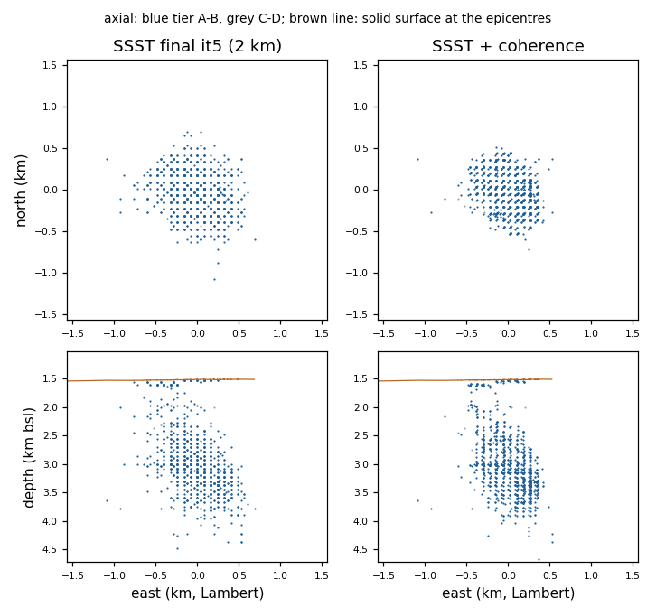

### blanco

| arm | located | tier A-B | above surface | floor-limited | median depth km | depth below seafloor km | P rms s | S rms s | CC pair MAD ms (P / S) | catalog-dt pair MAD ms | repeater distance km (median) | nearest neighbour km | moved vs static: dh / dz km |
| --- | --- | --- | --- | --- | --- | --- | --- | --- | --- | --- | --- | --- | --- |
| v5.1 catalog (tile box) | 1,044 | 0 | 0 | 3 | 5.66 | 2.28 |  |  |  |  | 0.440 | 0.237 |  |
| no terms (it0) | 1,044 | 0 | 0 | 5 | 5.42 | 2.10 | 0.311 | 0.305 | 35.4 (28.6 / 43.5) | 42.4 | 0.717 | 0.279 |  |
| SSST it1 (static, 9999 km) | 1,044 | 0 | 0 | 2 | 5.55 | 2.21 | 0.126 | 0.143 | 24.6 (19.4 / 31.3) | 33.8 | 0.416 | 0.235 |  |
| SSST it2 (16 km) | 1,044 | 0 | 0 | 2 | 5.59 | 2.25 | 0.113 | 0.131 | 24.3 (19.1 / 30.9) | 33.7 | 0.460 | 0.228 |  |
| SSST it3 (8 km) | 1,044 | 0 | 0 | 1 | 5.59 | 2.26 | 0.110 | 0.122 | 24.0 (18.9 / 30.4) | 32.7 | 0.415 | 0.235 |  |
| SSST it4 (4 km) | 1,044 | 0 | 0 | 1 | 5.66 | 2.28 | 0.107 | 0.114 | 23.5 (18.7 / 29.4) | 32.5 | 0.400 | 0.241 |  |
| SSST final it5 (2 km) | 1,044 | 2 | 0 | 1 | 5.66 | 2.30 | 0.103 | 0.107 | 23.9 (19.3 / 29.4) | 32.5 | 0.449 | 0.247 |  |
| SSST + coherence | 1,044 | 2 | 0 | 1 | 5.66 | 2.30 | 0.103 | 0.110 | 23.6 (19.2 / 29.0) | 32.5 | 0.447 | 0.235 |  |

Depth minus published depth (Lange et al. 2026), km, positive = ours deeper:

[output not shown]

SSST + coherence: 72 of 1044 events relocated (ellipsoid len3 ≤ 5.0 km), 62 with at least one partner of coherence ≥ 0.5 that passes the same filter; 10909 pairs.

Loc2ssst runs: ssst_it0: CharDist 9999 km, 1025 events, 63 grids, 0 negative nodes (max 0 km from the station), 2 s; ssst_it1: CharDist 16 km, 1036 events, 63 grids, 0 negative nodes (max 0 km from the station), 2 s; ssst_it2: CharDist 8 km, 1036 events, 63 grids, 0 negative nodes (max 0 km from the station), 3 s; ssst_it3: CharDist 4 km, 1038 events, 63 grids, 0 negative nodes (max 0 km from the station), 8 s; ssst_it4: CharDist 2 km, 1038 events, 63 grids, 0 negative nodes (max 0 km from the station), 51 s

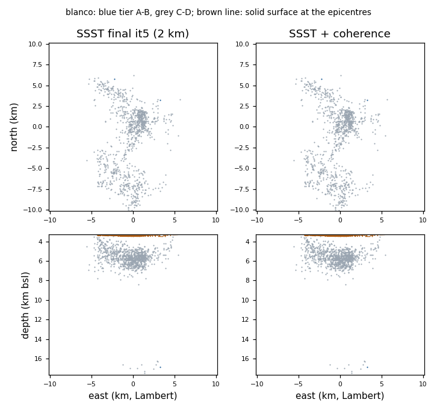

### msh

| arm | located | tier A-B | above surface | floor-limited | median depth km | depth below seafloor km | P rms s | S rms s | CC pair MAD ms (P / S) | catalog-dt pair MAD ms | repeater distance km (median) | nearest neighbour km | moved vs static: dh / dz km |
| --- | --- | --- | --- | --- | --- | --- | --- | --- | --- | --- | --- | --- | --- |
| v5.1 catalog (tile box) | 1,436 | 1,311 | 0 | 0 | 1.18 | 3.25 |  |  |  |  | 0.215 | 0.084 |  |
| no terms (it0) | 1,436 | 1,312 | 0 | 6 | 1.75 | 3.81 | 0.163 | 0.288 | 30.3 (26.0 / 41.2) | 46.6 | 0.530 | 0.113 |  |
| SSST it1 (static, 9999 km) | 1,436 | 1,334 | 0 | 1 | 1.60 | 3.67 | 0.114 | 0.178 | 17.6 (15.1 / 24.1) | 37.6 | 0.227 | 0.084 |  |
| SSST it2 (16 km) | 1,436 | 1,333 | 0 | 1 | 1.47 | 3.57 | 0.111 | 0.172 | 17.3 (15.1 / 22.9) | 37.0 | 0.224 | 0.070 |  |
| SSST it3 (8 km) | 1,436 | 1,336 | 0 | 1 | 1.41 | 3.50 | 0.110 | 0.170 | 17.2 (15.3 / 22.6) | 37.2 | 0.231 | 0.070 |  |
| SSST it4 (4 km) | 1,436 | 1,333 | 0 | 1 | 1.36 | 3.44 | 0.109 | 0.168 | 17.2 (15.2 / 22.1) | 36.8 | 0.228 | 0.070 |  |

Depth minus published depth (Hirao et al. 2025), km, positive = ours deeper:

| arm | tiers A-D: median [p10, p90] | tiers A-B |
| --- | --- | --- |
| v5.1 catalog (tile box) | +0.92 [-0.4, +2.2] n=1258 | +0.95 [-0.4, +2.2] n=1171 |
| no terms (it0) | +1.52 [-0.0, +2.9] n=1258 | +1.53 [+0.1, +2.9] n=1168 |
| SSST it1 (static, 9999 km) | +1.36 [+0.2, +2.4] n=1258 | +1.37 [+0.2, +2.4] n=1185 |
| SSST it2 (16 km) | +1.25 [+0.1, +2.3] n=1258 | +1.27 [+0.1, +2.3] n=1183 |
| SSST it3 (8 km) | +1.17 [+0.0, +2.2] n=1258 | +1.19 [+0.0, +2.2] n=1186 |
| SSST it4 (4 km) | +1.13 [-0.0, +2.2] n=1258 | +1.14 [-0.0, +2.2] n=1182 |

Loc2ssst runs: ssst_it0: CharDist 9999 km, 1381 events, 204 grids, 18 negative nodes (max 0.86 km from the station), 14 s; ssst_it1: CharDist 16 km, 1386 events, 204 grids, 21 negative nodes (max 0.86 km from the station), 8 s; ssst_it2: CharDist 8 km, 1388 events, 204 grids, 22 negative nodes (max 0.87 km from the station), 9 s; ssst_it3: CharDist 4 km, 1389 events, 204 grids, 19 negative nodes (max 0.87 km from the station), 15 s; ssst_it4: CharDist 2 km, 1388 events, 204 grids, 17 negative nodes (max 0.87 km from the station), 96 s

### jdf

| arm | located | tier A-B | above surface | floor-limited | median depth km | depth below seafloor km | P rms s | S rms s | CC pair MAD ms (P / S) | catalog-dt pair MAD ms | repeater distance km (median) | nearest neighbour km | moved vs static: dh / dz km |
| --- | --- | --- | --- | --- | --- | --- | --- | --- | --- | --- | --- | --- | --- |
| v5.1 catalog (tile box) | 162 | 0 | 0 | 156 | 2.75 | 0.02 |  |  |  |  | 0.473 | 0.161 |  |
| no terms (it0) | 162 | 0 | 0 | 140 | 2.75 | 0.02 | 0.179 | 0.356 | 60.2 (43.7 / 79.3) | 74.4 | 0.977 | 0.212 |  |
| SSST it1 (static, 9999 km) | 162 | 0 | 0 | 127 | 2.75 | 0.03 | 0.117 | 0.211 | 34.2 (27.2 / 44.6) | 49.8 | 0.400 | 0.156 |  |
| SSST it2 (16 km) | 162 | 1 | 0 | 89 | 2.78 | 0.07 | 0.107 | 0.171 | 36.6 (30.7 / 44.4) | 48.8 | 0.462 | 0.207 |  |
| SSST it3 (8 km) | 162 | 2 | 0 | 50 | 3.08 | 0.36 | 0.105 | 0.147 | 43.8 (38.1 / 51.2) | 49.3 | 0.819 | 0.260 |  |
| SSST it4 (4 km) | 162 | 3 | 0 | 28 | 3.36 | 0.64 | 0.101 | 0.135 | 40.4 (33.0 / 49.6) | 47.5 | 0.832 | 0.356 |  |
| SSST final it5 (2 km) | 162 | 3 | 0 | 23 | 25.68 | 22.99 | 0.088 | 0.120 | 40.1 (31.1 / 52.2) | 43.1 | 1.040 | 0.406 |  |
| SSST + coherence | 162 | 3 | 0 | 22 | 21.93 | 19.25 | 0.097 | 0.149 | 40.4 (31.5 / 53.2) | 44.1 | 1.040 | 0.402 |  |

SSST + coherence: 9 of 162 events relocated (ellipsoid len3 ≤ 5.0 km), 9 with at least one partner of coherence ≥ 0.5 that passes the same filter; 2039 pairs.

Loc2ssst runs: ssst_it0: CharDist 9999 km, 120 events, 16 grids, 1 negative nodes (max 0.45 km from the station), 0 s; ssst_it1: CharDist 16 km, 138 events, 16 grids, 1 negative nodes (max 0.45 km from the station), 0 s; ssst_it2: CharDist 8 km, 147 events, 16 grids, 2 negative nodes (max 0.79 km from the station), 0 s; ssst_it3: CharDist 4 km, 161 events, 16 grids, 3 negative nodes (max 0.79 km from the station), 1 s; ssst_it4: CharDist 2 km, 161 events, 16 grids, 3 negative nodes (max 0.79 km from the station), 6 s

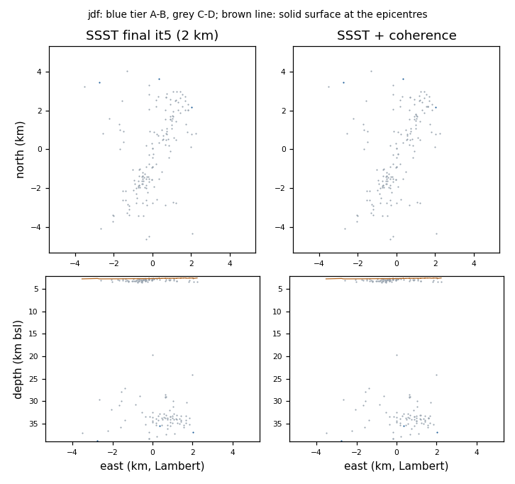

## Plan for the catalog v6.0 relocation (D-B079, D-B092)

Draft for the PI, 2026-11-25. Catalog v6.0 is the NonLinLoc relocation of all 172,342 catalog v4.1 events in model v0.4.1, with the clock-corrected picks and the station-term method the PI chooses from the test in this report. It runs after the PI's review of the remaining clock-candidate epochs (D-B090). Every output goes to `/wd1/mdenolle_data/reloc_v6`; the driver is `workflow/10_tomography/b4_v6_relocate.sh` (branch `reloc/v6-prep`).

| input | file | state |
| --- | --- | --- |
| fine grids | `reloc_v6/time_v6_v0.4.1` (1,392 station-phases) | built by the chain (stage grids) |
| wide and deep grids | `reloc_v6/wide_time_v6_v0.4.1` | built by the chain (stage wide) |
| grid identity | `reloc_v6/grids_time_v6_v0.4.1.md5` (md5 of every grid file) | stage manifest |
| picks | `checks/pick_timing_v6/Cascadia_picks_catalog_v4.1tc.csv` (md5 1b21ab1c) | to be replaced if the PI confirms more clock epochs |
| events | catalog v4.1 event list | unchanged |
| floor | `reloc_v5/topo/topo_15s_cons_merged_eft.bin` (D-B056, D-B068) | md5 checked by stage surface |
| review flags | `catalog_v5/v5.1_review/returned/review_*.csv` (ingest_review.py) | filled when the reviews come back |

### Stages and run time

Run time below is for 16 processes on the loaded machine, scaled from the v5.1 run (iter0 and iter1: 39 and 38 min with 100 processes, about 65 process-hours each) and from the cluster test (NLLoc 1,200 events in 40-57 s with 4 processes; Loc2ssst about 26 ns per grid node and arrival).

| stage | what | time at 16 processes |
| --- | --- | --- |
| surface, grids, wide, manifest | done today (grids 2026-11-25) | (see grid status) |
| obs | a2_make_obs.py from the final pick file into `obs_tiles_v6` | 2 min |
| smoke | three tiles (Cascades, Axial, Blanco), no refusal, no undocumented arrival drop, 0 events above the surface | 20 min |
| iter0 | NLLoc, no terms (LOCGAU 0.2 0.0 without LOCGAU2, D-B069; minimum 5 phases, D-B066; merged floor; fine then wide grids) | 4 h |
| terms | static terms from iter0 (a2_station_terms.py), as v5.1 | 1 min |
| iter1 | NLLoc with the iter0 static terms | 4 h |
| SSST (if chosen) | per tile block: Loc2ssst, then NLLoc with the corrected grids, one pass per CharDist | about 4.5 h per pass |
| deep | events rejected at the bottom face or at z' >= 78 km, z' -5..120 km with the wide grids (D-B067) | 10 min |
| coherence (if chosen) | only events with CC partners (D-B040 families); needs CC for every family first | per family |
| catalog | a2_parse_hyp.py, a2_build_catalog.py, b4_catalog.py, b4_acceptance.py, b4_lit_paired.py | 15 min |
| publish | reports committed, `reloc_v6/b4_v6.DONE` for session -18 | 1 min |

Static terms only: about 9 hours. Each SSST pass adds about 4.5 hours (one NLLoc pass plus Loc2ssst). With the PI's leave to use 64 processes the NLLoc passes take about 1 hour each.

### Station terms: what the test supports so far

Method test on the v5.1 grids (Axial and JdF complete on 2026-11-25 11:35; Blanco, Mount St Helens and the coherence arms finish in the background, see `reloc_v6/ssst_test/run_g51_coh.log`):

The options for the PI:

- **static (as v5.1)**: iter0, static terms, iter1.
- **regional SSST**: Loc2ssst with large CharDist only (static step, then 16 and 8 km). Close to static at Axial, better at JdF; small CharDist (4, 2 km) is not supported by the test.
- **coherence**: the step that sharpened Axial most, but it needs waveform CC for every family (today only the four test sets) and applies only to events with a compact pdf (ellipsoid len3 at most 5 km).

### Native NLL-SSST at catalog scale

Loc2ssst (NonLinLoc 7.1.07) has fixed limits: 100,000 events per run (`MAX_NUM_INPUT_FILES`) and 20,000 arrivals per station-phase (`MAX_NUM_ARRIVALS_LOC2SSST`, more are dropped with an ERROR), and one output grid geometry (`LSOUTGRID`) for all station-phases of a run. The whole catalog has 2.5 million arrivals, so SSST runs per region:

- blocks of tiles (25 km), each block's Loc2ssst reading the events of the block plus a halo of 3 x CharDist. Per tile the largest station-phase count is 15,334 arrivals (t07_32, Axial), below the limit; 13 station-phases exceed 20,000 over the whole catalog (B932.PB, B047.PB, AXEC1.OO, AXEC3.OO ...), so Axial blocks with halos must stay small;
- `LSOUTGRID` = the block's NLLoc search box. The tiles hold 97,436 station-phases in total (median 41 per tile, max 603). With the production box (tile +- 75 km, 175 x 175 x 86 nodes, 10.5 MB per grid) one iteration writes about 1 TB; with tile +- 15 km (55 x 55 x 86, 1.0 MB) about 100 GB. The previous iteration is the next one's input, so two iterations are on disk at a time;
- Loc2ssst cost: (LSGRID nodes) x (arrivals of the block) at about 26 ns each (measured: Axial 4.2e9 in 28.5 s and Blanco 5.7e9 in 36 s with 4 instances): with tile +- 15 km boxes and halos about 0.4 process-hours per iteration at LSGRID 4 km (CharDist 8-16 km), 3 at 2 km, 24 at 1 km;
- station sets per Loc2ssst instance must not contain a station code that is a substring of another set's string (`LSSTATIONS` is matched with strstr); b4_v6_ssst.station_sets checks this.

An alternative that needs no new grids: apply each event's source-specific correction (the same Gaussian-weighted mean of its neighbours' residuals, computed at the event's previous position) to its pick times and rerun NLLoc with the static grids. It is the classic SSST of Richards-Dinger and Shearer (2000) rather than NonLinLoc's grid form; the correction does not follow the trial hypocentre inside one NLLoc search. Not built: the test does not support small CharDist, so it is not needed now.

### Picks and clock corrections

The obs stage pins the pick file by md5 (`PICKS`, `PICKS_MD5` in the chain). When the PI confirms more clock epochs (D-B090), the pick-timing toolkit writes a new pick file; the chain then reruns from obs (the grids do not depend on the picks). The pick file the catalog was located with goes into the catalog bundle (D-B080).

### Location-review flags

ingest_review.py writes `review_flag_not_earthquake.csv`, `review_depth_unreliable.csv` and `review_relocate.csv`. b4_catalog.py joins them by ID when the catalog is built. They are flags only: no hypocentre is moved or removed (D-B055). A reviewer's corrected depth is kept as information, never written into `depth`.

### Catalog columns to add for session -18

All v5.1 columns stay. New columns:

| column | type | meaning |
| --- | --- | --- |
| model_version | str | velocity model of the travel-time grids (v0.4.1) |
| station_terms | str | `static` (iter0 terms, as v5.1) or `ssst` |
| ssst_char_km | float | final Loc2ssst CharDist of the event's region (empty with static terms) |
| rms_unweighted | float | unweighted rms of the used arrivals, s (NLLoc's RMS is EDT-weighted, D-B069) |
| n_picks_retimed | int | picks of the event re-timed (D-B072/D-B075) |
| n_picks_clock_corrected | int | picks corrected for a station clock drift (D-B090) |
| shift_h_v51_km, shift_z_v51_km | float | change from catalog v5.1 (horizontal, depth; positive = deeper) |
| review_not_earthquake | bool | a reviewer flagged the event as not an earthquake |
| review_depth_unreliable | bool | a reviewer flagged the depth as unreliable or implausible |
| review_relocate | bool | a reviewer asked for a relocation |
| review_depth_km | float | the reviewer's depth, information only (never applied) |
| coherence_relocated | bool | relocated by NLL-coherence (only if that stage runs) |
| coherence_partners | int | partners stacked by NLL-coherence |

The README states the grid set (`grids_time_v6_v0.4.1.md5` md5), the pick file md5 and the floor file. Magnitudes: the converged phase19 solution (D-B091) recomputed on the v6.0 hypocentres.

### Open before the full run

1. PI: station-term method (static, regional SSST, coherence later). 2. PI: the remaining clock-candidate epochs (D-B090), then the final pick file. 3. The v0.4.1 cluster test (`ssst_test/g041`), which runs automatically after the grids. 4. Process budget for the NLLoc passes (16 processes: about 4 hours per pass).